[O’Hara on GitHub](https://github.com/oharac)

# Compare cumulative impacts per species to IUCN status

Compiled on Sat Jul 2 13:57:20 2022 by ohara

```r
knitr::opts_chunk$set(echo = TRUE, message = FALSE, warning = FALSE)

library(tidyverse)
library(here)
library(oharac)
source(here('common_fxns.R'))
```

# 1 Summary

Calculate the cumulative impact across each species range (total and coastal-only). Relative CHI will be the total CHI (summed across all cells and all stressors) normalized by the total range (total and coastal-only). The relative CHI is effectively the average CHI per km<sup>2</sup> across the species’ range.

Perform a regression of IUCN extinction risk classification as a function of relative overall CHI and overall range, and then do the same for coastal.

# 2 Data

- Species impact scores from script 6
- IUCN extinction risk scores from IUCN

# 3 Methods

## 3.1 Read in species impacts for those spp assessed by IUCN; summarize to CHI

Summarize to cumulative impacts by entire range and by coastal range.

Each file has a row for each stressor-vulnerability match; columns are:

- `str_vuln` (chr): name of stressor/vuln combo, as -
- `impact_tot` (dbl): sum across all cells of stressor intensity $\times$ vulnerability $\times$ ocean area
- `impact_coastal` (dbl): sum across all coastal cells (≤200m) of stressor intensity $\times$ vulnerability $\times$ ocean area
- `range_tot_km2` (dbl): sum of ocean area of all cells across entire range
- `range_coastal_km2` (dbl): sum of ocean area of all cells across coastal range

```r
spp_chi_file <- here_anx('int/spp_chi_summary.csv')

if(!file.exists(spp_chi_file)) { ### unlink(spp_chi_file)
  spp_imp_fs <- list.files(here_anx('impacts_by_species'),
                           pattern = '^impacts_.+.csv', full.names = TRUE)

  spp_imp_raw_df <- parallel::mclapply(spp_imp_fs, mc.cores = 40,
                                       data.table::fread) %>%
    setNames(basename(spp_imp_fs)) %>%
    data.table::rbindlist(idcol = 'f') %>%
    rename(vuln = vulnerability)

  spp_ranges <- spp_imp_raw_df %>%
    select(f, range_km2, range) %>%
    distinct() %>%
    spread(range, range_km2) %>%
    rename(range_cst_km2 = coastal, range_tot_km2 = full)

  spp_intensity_df <- spp_imp_raw_df %>%
    select(f, vuln, stressor, intensity_tot, range) %>%
    spread(range, intensity_tot) %>%
    rename(intensity_tot = full, intensity_cst = coastal)

  spp_intens_cv_df <- spp_imp_raw_df %>%
    select(f, vuln, stressor, intensity_cv, range) %>%
    spread(range, intensity_cv) %>%
    rename(intensity_cv_tot = full, intensity_cv_cst = coastal)

  spp_impacts_df <- spp_imp_raw_df %>%
    select(f, vuln, stressor, impact_tot, range) %>%
    spread(range, impact_tot) %>%
    rename(impact_tot = full, impact_cst = coastal)

  spp_cv_df <- spp_imp_raw_df %>%
    select(f, vuln, stressor, impact_cv, range) %>%
    spread(range, impact_cv) %>%
    rename(impact_cv_tot = full, impact_cv_cst = coastal)

  spp_impacts_npp_df <- spp_imp_raw_df %>%
    select(f, vuln, stressor, impact_npp_tot, range) %>%
    spread(range, impact_npp_tot) %>%
    rename(impact_npp_tot = full, impact_npp_cst = coastal)

  spp_npp_cv_df <- spp_imp_raw_df %>%
    select(f, vuln, stressor, impact_npp_cv, range) %>%
    spread(range, impact_npp_cv) %>%
    rename(impact_npp_cv_tot = full, impact_npp_cv_cst = coastal)

  iucn_worms_lookup <- read_csv(here('_data/iucn_spp', 'iucn_to_worms_match.csv'))

  spp_imp_cv_df <- full_join(spp_impacts_df, spp_cv_df,
                             by = c('f', 'vuln', 'stressor')) %>%
    full_join(spp_impacts_npp_df, by = c('f', 'vuln', 'stressor')) %>%
    full_join(spp_npp_cv_df, by = c('f', 'vuln', 'stressor')) %>%
    full_join(spp_intensity_df, by = c('f', 'vuln', 'stressor')) %>%
    full_join(spp_intens_cv_df, by = c('f', 'vuln', 'stressor')) %>%
    left_join(spp_ranges, by = 'f') %>%
    ### extract species and map info from filename
    mutate(map_src = str_extract(f, '_iucn_|_am_') %>% str_remove_all('_'),
           iucn_sid = str_extract(f, '[0-9]+') %>% as.integer(),
           spp_from_f = str_remove_all(f, 'impacts_(am|iucn)_|.csv')) %>%
    left_join(iucn_worms_lookup, by = 'iucn_sid') %>%
    mutate(sciname = ifelse(is.na(worms_name),
                            str_replace_all(spp_from_f, '_', ' '),
                            worms_name)) %>%
    ### append iucn_sid for spp not mapped in IUCN but mapped in AM:
    left_join(iucn_worms_lookup %>% select(sciname = worms_name, iucn_sid2 = iucn_sid),
              by = c('sciname')) %>%
    mutate(iucn_sid = ifelse(is.na(iucn_sid), iucn_sid2, iucn_sid)) %>%
    select(sciname, iucn_sid, map_src, vuln, stressor,
           impact_cst, impact_tot, impact_cv_cst, impact_cv_tot,
           impact_npp_cst, impact_npp_tot,
           impact_npp_cv_cst, impact_npp_cv_tot,
           intensity_cst, intensity_tot,
           intensity_cv_cst, intensity_cv_tot,
           range_cst_km2, range_tot_km2) %>%
    distinct() %>%
    filter(range_tot_km2 > 0 & !is.na(impact_tot))

  write_csv(spp_imp_cv_df, spp_chi_file)
}
```

## 3.2 Examine means across taxa

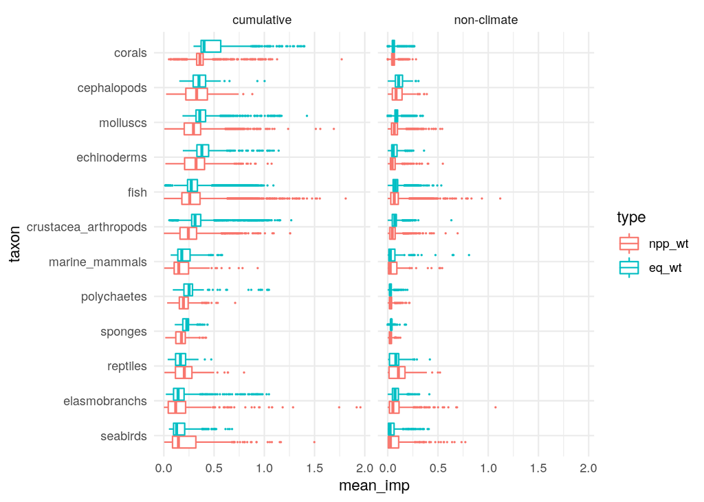

```r
vuln_taxa <- get_spp_vuln() %>%
  select(species, taxon) %>%
  distinct()

spp_impacts <- read_csv(spp_chi_file) %>%
  filter(range_tot_km2 > 10000)

spp_chi <- spp_impacts %>%
  filter(stressor == 'cumulative') %>%
  mutate(eq_wt  = impact_tot / range_tot_km2,
         npp_wt = impact_npp_tot / range_tot_km2) %>%
  select(sciname, eq_wt, npp_wt, range_tot_km2) %>%
  distinct() %>%
  mutate(group = 'cumulative')

spp_no_cc <- spp_impacts %>%
  filter(vuln == 'stressor_group' & stressor != 'climate') %>%
  select(sciname, impact_tot, impact_npp_tot, range_tot_km2) %>%
  distinct() %>%
  mutate(imp_unwt_tot = impact_tot / range_tot_km2,
         imp_nppwt_tot = impact_npp_tot / range_tot_km2) %>%
  group_by(sciname) %>%
  summarize(eq_wt  = sum(imp_unwt_tot),
            npp_wt = sum(imp_nppwt_tot),
            range_tot_km2 = first(range_tot_km2)) %>%
  mutate(group = 'non-climate')

cum_plus_non_cc <- bind_rows(spp_chi, spp_no_cc) %>%
  left_join(vuln_taxa, by = c('sciname' = 'species')) %>%
  gather(type, mean_imp, eq_wt, npp_wt) %>%
  filter(!is.na(taxon))

taxon_order <- cum_plus_non_cc %>%
  filter(type == 'eq_wt') %>%
  group_by(taxon) %>%
  summarize(med_imp = median(mean_imp)) %>%
  arrange(med_imp) %>%
  .$taxon

plot_df <- cum_plus_non_cc %>%
  mutate(taxon = factor(taxon, levels = taxon_order)) %>%
  mutate(type = factor(type, levels = c('npp_wt', 'eq_wt')))

ggplot(plot_df,
       aes(y = taxon, x = mean_imp)) +
  geom_boxplot(aes(color = type),
               outlier.size = .1) +
  theme_minimal() +
  facet_wrap( ~ group)
```

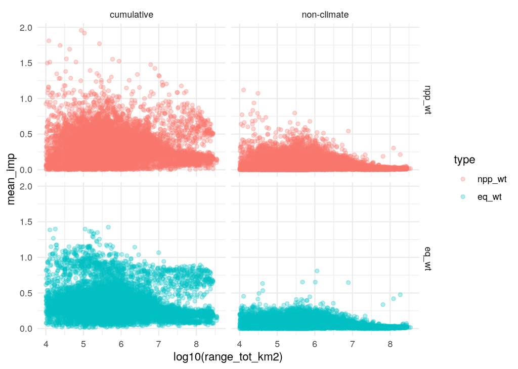

```r
ggplot(plot_df, aes(x = log10(range_tot_km2), y = mean_imp)) +
  geom_point(aes(color = type), alpha = .3) +
  theme_minimal() +
  facet_grid(type ~ group)
```

```r
summary_by_taxon <- cum_plus_non_cc %>%
  group_by(taxon, type, group) %>%
  summarize(mu_tot = mean(mean_imp) %>% round(4),
            sd_tot = sd(mean_imp) %>% round(4)) %>%
  arrange(group, type, desc(mu_tot))

DT::datatable(summary_by_taxon)
```

|  | taxon | type | group | mu_tot | sd_tot |
| --- | --- | --- | --- | --- | --- |
| 1 | corals | eq_wt | cumulative | 0.4918 | 0.1916 |
| 2 | echinoderms | eq_wt | cumulative | 0.4088 | 0.1333 |
| 3 | molluscs | eq_wt | cumulative | 0.3869 | 0.119 |
| 4 | cephalopods | eq_wt | cumulative | 0.3665 | 0.1094 |
| 5 | crustacea_arthropods | eq_wt | cumulative | 0.3581 | 0.1674 |
| 6 | fish | eq_wt | cumulative | 0.3082 | 0.1293 |
| 7 | polychaetes | eq_wt | cumulative | 0.2589 | 0.1156 |
| 8 | sponges | eq_wt | cumulative | 0.227 | 0.0517 |
| 9 | marine_mammals | eq_wt | cumulative | 0.2169 | 0.1136 |
| 10 | elasmobranchs | eq_wt | cumulative | 0.1839 | 0.1641 |

[output cut: 38 more lines]

### 3.2.1 Assemble IUCN Red List categories for species in IUCN maps and AquaMaps maps

```r
iucn_worms_lookup <- read_csv(here('_data/iucn_spp', 'iucn_to_worms_match.csv'),
                              show_col_types = FALSE)

iucn_comp <- read_csv(here('_data/iucn_spp/iucn_comp_assessed_2021-3.csv'))
iucn_assessed <- read_csv(here('_data/iucn_spp/iucn_marine_spp_info_2021-3.csv'),
                              show_col_types = FALSE) %>%
  filter(iucn_sid %in% iucn_comp$iucn_sid) %>%
  select(iucn_sid, cat, cat_score) %>%
  left_join(iucn_worms_lookup, by = 'iucn_sid') %>%
  mutate(threatened = case_when(cat == 'dd' ~ NA,
                                cat %in% c('lc', 'nt') ~ FALSE,
                                TRUE ~ TRUE),
         atrisk     = case_when(cat == 'dd' ~ NA,
                                cat %in% c('lc') ~ FALSE,
                                TRUE ~ TRUE)) %>%
  select(iucn_sid, iucn_sciname = sciname, sciname = worms_name,
         cat, cat_score, threatened, atrisk)
```

### 3.2.2 Combine IUCN categories with impacts

```r
iucn_impacts_df <- read_csv(spp_chi_file,
                            show_col_types = FALSE) %>%
  inner_join(iucn_assessed, by = c('iucn_sid', 'sciname')) %>%
  mutate(iucn_fct = toupper(cat),
         iucn_fct = factor(iucn_fct, levels = c('LC', 'NT', 'VU', 'EN', 'CR', 'EX', 'DD')))

check_df <- iucn_impacts_df %>%
  select(sciname, iucn_sid, map_src) %>%
  distinct() %>%
  janitor::get_dupes(sciname)

spp_taxa <- assemble_worms() %>%
  select(sciname = species, phylum, class, order, family) %>%
  distinct() %>%
  inner_join(get_spp_vuln() %>%
             select(sciname = species, taxon) %>%
             distinct())

fished_spp <- iucn_impacts_df %>%
  filter(stressor == 'biomass_removal') %>%
  mutate(fished = impact_cst > 0 | impact_tot > 0) %>%
  select(sciname, iucn_sid, fished)

# traits <- get_spp_traits()

spp_chi_iucn_clean <- iucn_impacts_df %>%
  filter(stressor == 'cumulative') %>%
  mutate(chi_rel_tot = impact_tot / range_tot_km2,
         chi_rel_cst = impact_cst / range_cst_km2,
         chi_npp_tot = impact_npp_tot / range_tot_km2,
         chi_npp_cst = impact_npp_cst / range_cst_km2) %>%
  filter(!is.na(threatened)) %>%
  left_join(spp_taxa, by = 'sciname') %>%
  left_join(fished_spp, by = c('sciname', 'iucn_sid'))
```

## 3.3 Binomial logistic regression - CHI

Perform a binomial logistic regression of threatened status (threatened/not threatened) as a function of mean cumulative impact and range. Set up data frame to include a `threatened` column, where LC and NT are `FALSE` and VU, EN, and CR are `TRUE`. Include range as inverse log of range, for both overall range and coastal-only range.

### 3.3.1 Prob of threatened = TRUE as function of CHI and range

```r
chi_threatened_valid <- spp_chi_iucn_clean %>%
  filter(!is.na(threatened)) %>%
  mutate(log_r_tot  = log(range_tot_km2),
         log_r_cst  = log(range_cst_km2)) %>%
  left_join(get_fe_traits(), by = c('sciname' = 'species'))
```

```r
df_for_blr_chi <- chi_threatened_valid %>%
  select(sciname, taxon, phylum, class, atrisk, threatened,
         starts_with('impact'), starts_with('chi'),
         starts_with('log'), starts_with('range'),
         mob, len, wcol, trp) %>%
  distinct() %>%
  mutate(qtile_r = ntile(range_tot_km2, n = 5)) %>%
  drop_na()

df_for_blr_chi %>% group_by(qtile_r) %>% summarize(r = max(range_tot_km2))
```

```
## # A tibble: 5 × 2
##   qtile_r          r
##     <int>      <dbl>
## 1       1     85919
## 2       2    364999
## 3       3   1136895
## 4       4   3925062.
## 5       5 347400858.
```

```r
### across all spp, coastal ranges, NPP-weighted mean and CV
mdl1 <- glm(threatened ~ chi_npp_cst + impact_npp_cv_cst + log_r_cst,
           data = df_for_blr_chi %>% filter(qtile_r <= 4),
           family = 'binomial')
summary(mdl1) ### AIC 3952.8
```

```
##
## Call:
## glm(formula = threatened ~ chi_npp_cst + impact_npp_cv_cst +
##     log_r_cst, family = "binomial", data = df_for_blr_chi %>%
##     filter(qtile_r <= 4))
##
## Deviance Residuals:
##     Min       1Q   Median       3Q      Max
## -1.8826  -0.6169  -0.5712  -0.5383   2.0673
##
## Coefficients:
##                   Estimate Std. Error z value Pr(>|z|)
## (Intercept)       -1.60042    0.26921  -5.945 2.77e-09 ***
## chi_npp_cst        1.08733    0.15891   6.842 7.80e-12 ***
## impact_npp_cv_cst  0.19750    0.04824   4.094 4.23e-05 ***
## log_r_cst         -0.07036    0.01764  -3.988 6.67e-05 ***
## ---
## Signif. codes:  0 '***' 0.001 '**' 0.01 '*' 0.05 '.' 0.1 ' ' 1
##
## (Dispersion parameter for binomial family taken to be 1)
##
##     Null deviance: 4009.7  on 4327  degrees of freedom
## Residual deviance: 3932.3  on 4324  degrees of freedom
## AIC: 3940.3
##
## Number of Fisher Scoring iterations: 4
```

```r
#                   Estimate Std. Error z value Pr(>|z|)
# (Intercept)       -1.57527    0.27181  -5.795 6.81e-09 ***
# chi_npp_cst        0.83270    0.14445   5.765 8.18e-09 ***
# impact_npp_cv_cst  0.20509    0.04959   4.136 3.53e-05 ***
# log_r_cst         -0.06907    0.01770  -3.902 9.52e-05 ***
with(summary(mdl1), 1 - deviance/null.deviance) ### McFadden's R^2
```

```
## [1] 0.01928593
```

```r
# 0.01617018

### similar but total ranges rather than coastal ranges
mdl2 <- glm(threatened ~ chi_npp_tot + impact_npp_cv_tot + log_r_tot,
           data = df_for_blr_chi %>% filter(qtile_r <= 4),
           family = 'binomial')
summary(mdl2) ### AIC 3942.1
```

```
##
## Call:
## glm(formula = threatened ~ chi_npp_tot + impact_npp_cv_tot +
##     log_r_tot, family = "binomial", data = df_for_blr_chi %>%
##     filter(qtile_r <= 4))
##
## Deviance Residuals:
##     Min       1Q   Median       3Q      Max
## -1.9539  -0.6188  -0.5755  -0.5386   2.0631
##
## Coefficients:
##                   Estimate Std. Error z value Pr(>|z|)
## (Intercept)       -1.13322    0.26237  -4.319 1.57e-05 ***
## chi_npp_tot        1.14420    0.17187   6.657 2.79e-11 ***
## impact_npp_cv_tot  0.10103    0.03577   2.825  0.00473 **
## log_r_tot         -0.08444    0.01843  -4.581 4.63e-06 ***
## ---
## Signif. codes:  0 '***' 0.001 '**' 0.01 '*' 0.05 '.' 0.1 ' ' 1
##
## (Dispersion parameter for binomial family taken to be 1)
##
##     Null deviance: 4009.7  on 4327  degrees of freedom
## Residual deviance: 3929.5  on 4324  degrees of freedom
## AIC: 3937.5
##
## Number of Fisher Scoring iterations: 4
```

```r
#                  Estimate Std. Error z value Pr(>|z|)
# (Intercept)       -1.14481    0.26082  -4.389 1.14e-05 ***
# chi_npp_tot        0.95255    0.15677   6.076 1.23e-09 ***
# impact_npp_cv_tot  0.13939    0.03849   3.622 0.000293 ***
# log_r_tot         -0.08957    0.01853  -4.835 1.33e-06 ***
with(summary(mdl2), 1 - deviance/null.deviance)
```

```
## [1] 0.01998625
```

```r
# 0.01885638

mdl2a <- glm(threatened ~ chi_npp_tot + impact_npp_cv_tot + log_r_tot,
           data = df_for_blr_chi %>% filter(qtile_r <= 5),
           family = 'binomial')
summary(mdl2a) ### AIC not comparable to qtile <= 4 version...
```

```
##
## Call:
## glm(formula = threatened ~ chi_npp_tot + impact_npp_cv_tot +
##     log_r_tot, family = "binomial", data = df_for_blr_chi %>%
##     filter(qtile_r <= 5))
##
## Deviance Residuals:
##     Min       1Q   Median       3Q      Max
## -1.9041  -0.6303  -0.5969  -0.5588   2.0736
##
## Coefficients:
##                   Estimate Std. Error z value Pr(>|z|)
## (Intercept)       -2.19798    0.21887 -10.042  < 2e-16 ***
## chi_npp_tot        1.17142    0.16706   7.012 2.35e-12 ***
## impact_npp_cv_tot  0.19818    0.02700   7.341 2.12e-13 ***
## log_r_tot         -0.01891    0.01451  -1.303    0.192
## ---
## Signif. codes:  0 '***' 0.001 '**' 0.01 '*' 0.05 '.' 0.1 ' ' 1
##
## (Dispersion parameter for binomial family taken to be 1)
##
##     Null deviance: 5142.7  on 5415  degrees of freedom
## Residual deviance: 5062.4  on 5412  degrees of freedom
## AIC: 5070.4
##
## Number of Fisher Scoring iterations: 4
```

```r
#                   Estimate Std. Error z value Pr(>|z|)
# (Intercept)       -2.17066    0.21657 -10.023  < 2e-16 ***
# chi_npp_tot        0.98133    0.15286   6.420 1.37e-10 ***
# impact_npp_cv_tot  0.23103    0.02869   8.053 8.05e-16 ***
# log_r_tot         -0.02551    0.01462  -1.745    0.081 .
with(summary(mdl2a), 1 - deviance/null.deviance)
```

```
## [1] 0.01561396
```

```r
# 0.01651841

### NPP-weighted mean CHI, drop CV term, (log_r term
### becomes insignificant when including top 20%)
mdl3 <- glm(threatened ~ chi_npp_tot + log_r_tot,
           data = df_for_blr_chi %>%
             filter(qtile_r <= 4),
           family = 'binomial')
summary(mdl3) ### AIC 3952.4
```

```
##
## Call:
## glm(formula = threatened ~ chi_npp_tot + log_r_tot, family = "binomial",
##     data = df_for_blr_chi %>% filter(qtile_r <= 4))
##
## Deviance Residuals:
##     Min       1Q   Median       3Q      Max
## -1.7889  -0.6208  -0.5811  -0.5419   2.0747
##
## Coefficients:
##             Estimate Std. Error z value Pr(>|z|)
## (Intercept) -0.83924    0.23832  -3.522 0.000429 ***
## chi_npp_tot  1.02367    0.16442   6.226 4.78e-10 ***
## log_r_tot   -0.08003    0.01825  -4.386 1.15e-05 ***
## ---
## Signif. codes:  0 '***' 0.001 '**' 0.01 '*' 0.05 '.' 0.1 ' ' 1
##
## (Dispersion parameter for binomial family taken to be 1)
##
##     Null deviance: 4009.7  on 4327  degrees of freedom
## Residual deviance: 3937.1  on 4325  degrees of freedom
## AIC: 3943.1
##
## Number of Fisher Scoring iterations: 4
```

```r
#             Estimate Std. Error z value Pr(>|z|)
# (Intercept) -0.77482    0.23767  -3.260  0.00111 **
# chi_npp_tot  0.83066    0.15098   5.502 3.76e-08 ***
# log_r_tot   -0.08170    0.01825  -4.478 7.55e-06 ***
with(summary(mdl3), 1 - deviance/null.deviance)
```

```
## [1] 0.01811116
```

```r
# 0.01578526

### Unweighted CHI (not NPP weighted), with no CV term - flips sign on CHI
mdl4 <- glm(threatened ~ chi_rel_tot + log_r_tot,
           data = df_for_blr_chi %>%
             filter(qtile_r <= 4),
           family = 'binomial')
summary(mdl4) ### AIC 3978.1
```

```
##
## Call:
## glm(formula = threatened ~ chi_rel_tot + log_r_tot, family = "binomial",
##     data = df_for_blr_chi %>% filter(qtile_r <= 4))
##
## Deviance Residuals:
##     Min       1Q   Median       3Q      Max
## -0.9051  -0.6314  -0.5907  -0.5505   2.0079
##
## Coefficients:
##             Estimate Std. Error z value Pr(>|z|)
## (Intercept) -0.20941    0.27782  -0.754    0.451
## chi_rel_tot -0.12157    0.22886  -0.531    0.595
## log_r_tot   -0.10666    0.01961  -5.440 5.33e-08 ***
## ---
## Signif. codes:  0 '***' 0.001 '**' 0.01 '*' 0.05 '.' 0.1 ' ' 1
##
## (Dispersion parameter for binomial family taken to be 1)
##
##     Null deviance: 4009.7  on 4327  degrees of freedom
## Residual deviance: 3977.2  on 4325  degrees of freedom
## AIC: 3983.2
##
## Number of Fisher Scoring iterations: 4
```

```r
#             Estimate Std. Error z value Pr(>|z|)
# (Intercept)  0.10585    0.28015   0.378   0.7056
# chi_rel_tot -0.50470    0.22148  -2.279   0.0227 *
# log_r_tot   -0.12226    0.01978  -6.180 6.42e-10 ***
with(summary(mdl4), 1 - deviance/null.deviance)
```

```
## [1] 0.008090178
```

```r
# 0.009358484
```

For all these models, dropping the top 20% of range improves the significance of coefficient on the log range term, though all models show significance on the other terms when all range is included.

Logically, the NPP-weighted CHI is the more appropriate comparison, as areas with greater NPP are likely to have greater abundances of spp and/or be of greater ecological importance to the species (e.g., feeding grounds); therefore impacts on those areas seem likely to cause greater problems for the population.

### 3.3.2 Predictive power?

Do models 1, 2, or 3 have any reasonable predictive power?

```r
pred_1 <- df_for_blr_chi %>%
  filter(qtile_r <= 4) %>%
  mutate(prob_thr = predict(mdl1, type = 'response')) %>%
  mutate(pred_thr = prob_thr >= .5,
         correct = threatened == pred_thr)

table(pred_1 %>% select(pred_thr, threatened))
```

```
##         threatened
## pred_thr FALSE TRUE
##    FALSE  3560  748
##    TRUE     12    8
```

```r
#         threatened
# pred_thr FALSE TRUE
#    FALSE  3563  748
#    TRUE      9    8

pred_2 <- df_for_blr_chi %>%
  filter(qtile_r <= 4) %>%
  mutate(prob_thr = predict(mdl2, type = 'response')) %>%
  mutate(pred_thr = prob_thr >= .5,
         correct = threatened == pred_thr)

table(pred_2 %>% select(pred_thr, threatened))
```

```
##         threatened
## pred_thr FALSE TRUE
##    FALSE  3554  748
##    TRUE     18    8
```

```r
#         threatened
# pred_thr FALSE TRUE
#    FALSE  3558  747
#    TRUE     14    9

pred_3 <- df_for_blr_chi %>%
  filter(qtile_r <= 4) %>%
  mutate(prob_thr = predict(mdl3, type = 'response')) %>%
  mutate(pred_thr = prob_thr >= .5,
         correct = threatened == pred_thr)

table(pred_3 %>% select(pred_thr, threatened))
```

```
##         threatened
## pred_thr FALSE TRUE
##    FALSE  3558  748
##    TRUE     14    8
```

```r
### Proportion correct
prop_correct1 <- sum(pred_1$correct) / nrow(pred_1)
# .825
prop_correct2 <- sum(pred_2$correct) / nrow(pred_2)
# .824
prop_correct3 <- sum(pred_3$correct) / nrow(pred_3)
# .826

### does it predict better than random guessing given the proportion of
### threatened being known?
prop_thr <- sum(pred_1$threatened) / nrow(pred_1)
pred_acc <- prop_thr^2 + (1 - prop_thr)^2
# .712; better than random guessing even if proportion is known

### does it predict better than the "zero rule"?
zero_rule <- sum(1 - pred_1$threatened) / nrow(pred_1)
# .825; about the same as choosing the zero rule...
```

Predictive power of this model is not great…

## 3.4 Binomial logistic regression - by stressor group

### 3.4.1 Prob of threatened = TRUE as function of impact categories and range

Use the simple model from model 3 above, threatened ~ npp-weighted impact + log range, but impact by stressor group rather than cumulative.

```r
qtile_df <- iucn_impacts_df %>%
  filter(!is.na(threatened)) %>%
  select(sciname, threatened, range_tot_km2) %>%
  distinct() %>%
  mutate(qtile_r = ntile(range_tot_km2, n = 5)) %>%
  select(sciname, threatened, qtile_r)

df_for_blr_gps <- iucn_impacts_df %>%
  filter(!is.na(threatened)) %>%
  filter(vuln == 'stressor_group') %>%
  select(sciname, atrisk, threatened,
         stressor, vuln, impact_npp_tot, range_tot_km2) %>%
  distinct() %>%
  spread(key = stressor, value = impact_npp_tot) %>%
  mutate(log_r_tot = log(range_tot_km2)) %>%
  left_join(qtile_df, by = c('sciname', 'threatened'))

mdl5 <- glm(formula = threatened ~ land_based + ocean_based + fishing + climate + log_r_tot,
             data = df_for_blr_gps, family = 'binomial')
summary(mdl5)
```

```
##
## Call:
## glm(formula = threatened ~ land_based + ocean_based + fishing +
##     climate + log_r_tot, family = "binomial", data = df_for_blr_gps)
##
## Deviance Residuals:
##     Min       1Q   Median       3Q      Max
## -2.2873  -0.6601  -0.6466  -0.6143   2.1235
##
## Coefficients:
##               Estimate Std. Error z value Pr(>|z|)
## (Intercept) -1.032e+00  1.923e-01  -5.367 8.00e-08 ***
## land_based   5.335e-08  4.099e-07   0.130 0.896450
## ocean_based  8.561e-07  1.862e-07   4.597 4.28e-06 ***
## fishing      7.938e-07  1.747e-07   4.543 5.55e-06 ***
## climate     -5.828e-08  1.607e-08  -3.626 0.000288 ***
## log_r_tot   -3.303e-02  1.528e-02  -2.162 0.030610 *
## ---
## Signif. codes:  0 '***' 0.001 '**' 0.01 '*' 0.05 '.' 0.1 ' ' 1
##
## (Dispersion parameter for binomial family taken to be 1)
##
##     Null deviance: 5766.8  on 5770  degrees of freedom
## Residual deviance: 5691.8  on 5765  degrees of freedom
## AIC: 5703.8
##
## Number of Fisher Scoring iterations: 4
```

```r
#               Estimate Std. Error z value Pr(>|z|)
# (Intercept) -1.047e+00  1.925e-01  -5.438 5.38e-08 ***
# land_based   4.022e-08  4.103e-07   0.098 0.921901
# ocean_based  7.823e-07  1.863e-07   4.200 2.67e-05 ***
# fishing      8.215e-07  1.780e-07   4.615 3.92e-06 ***
# climate     -5.716e-08  1.621e-08  -3.526 0.000422 ***
# log_r_tot   -3.173e-02  1.530e-02  -2.074 0.038083 *
```